# Homework 3-2

Nithin Mahesh

### Multiple Linear Regression

The columns in the mtcars dataset are described below:

mpg Miles/(US) gallon cyl Number of cylinders disp Displacement (cu.in.) hp Gross horsepower drat Rear axle ratio wt Weight (1000 lbs) qsec 1/4 mile time vs V-shaped engine=0, Straight engine=1 (cylinders in a line). am Transmission (0 = automatic, 1 = manual) gear Number of forward gears carb Number of carburetors

You may look up R datasets here: https://stat.ethz.ch/R-manual/R-devel/library/datasets/html/00Index.html

Q1(5pts): Fit a linear model to the mtcars data set. Make mpg the outcome, and weight, horsepower, number of cylinders be the covariates. Call the summary function on the fitted model object to show the output info.

```r
fitCar <- lm(mpg ~ wt + hp + cyl, data = mtcars)
summary(fitCar)
```

```
##
## Call:
## lm(formula = mpg ~ wt + hp + cyl, data = mtcars)
##
## Residuals:
##     Min      1Q  Median      3Q     Max
## -3.9290 -1.5598 -0.5311  1.1850  5.8986
##
## Coefficients:
##             Estimate Std. Error t value Pr(>|t|)
## (Intercept) 38.75179    1.78686  21.687  < 2e-16 ***
## wt          -3.16697    0.74058  -4.276 0.000199 ***
## hp          -0.01804    0.01188  -1.519 0.140015
## cyl         -0.94162    0.55092  -1.709 0.098480 .
## ---
## Signif. codes:  0 '***' 0.001 '**' 0.01 '*' 0.05 '.' 0.1 ' ' 1
##
## Residual standard error: 2.512 on 28 degrees of freedom
## Multiple R-squared:  0.8431, Adjusted R-squared:  0.8263
## F-statistic: 50.17 on 3 and 28 DF,  p-value: 2.184e-11
```

Q2(5pts): Say which of the covariates seems to have the biggest influence on mpg? What evidence in the output supports your answer?

[output not shown]

Q3(5pts): What change on mpg would we expect to see if we added one cylinder to an engine- holding hp and wt constant?

[output not shown]

Q4(2pts): What percent of the variance in the data is “explained” by this model?

[output not shown]

Q5(2pts): According to the output, what is the standard deviation of the errors from the fit?

[output not shown]

Q6(5pts): Display a plot of the residuals vs the fitted values- you can get these vectors from the fit object. Add a horizontal line at 0. The points should be evenly dispersed above and below the line with no noticeable pattern.

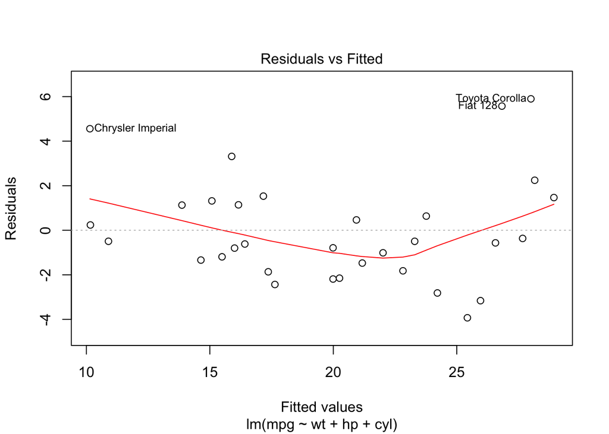

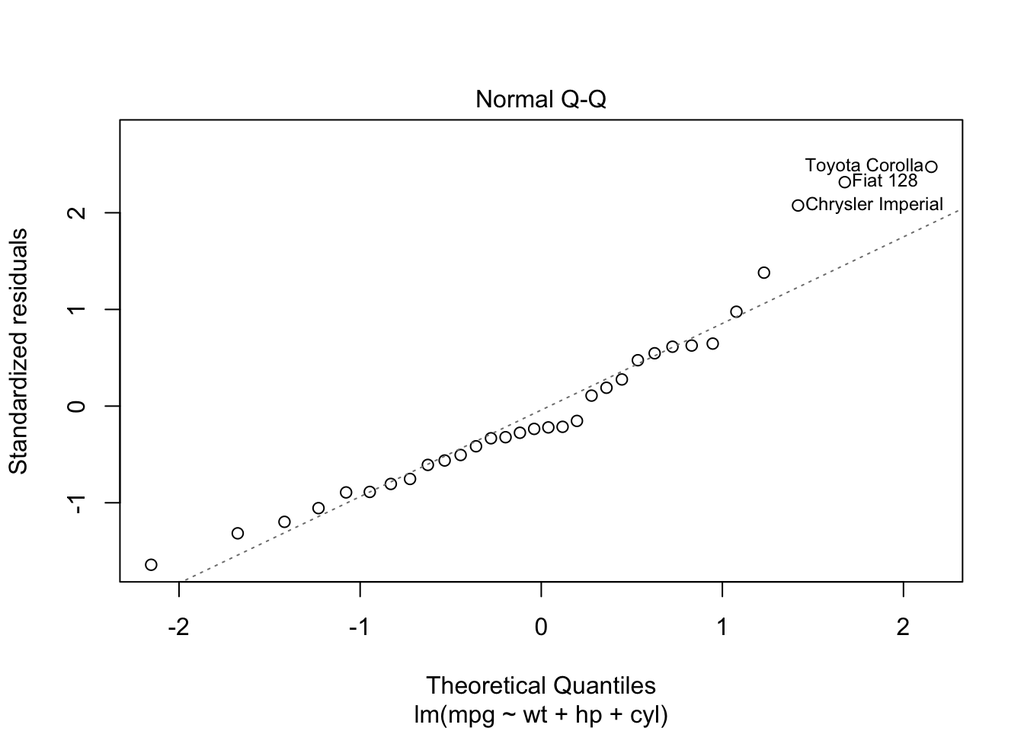

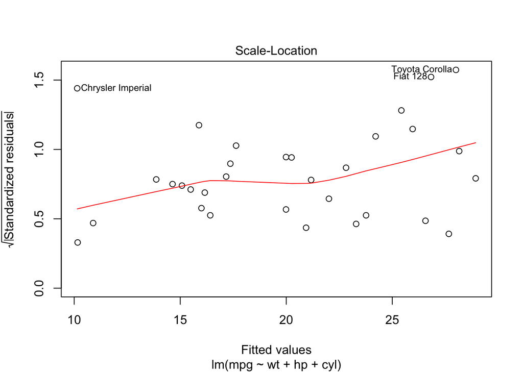

```r
plot(fitCar)
```

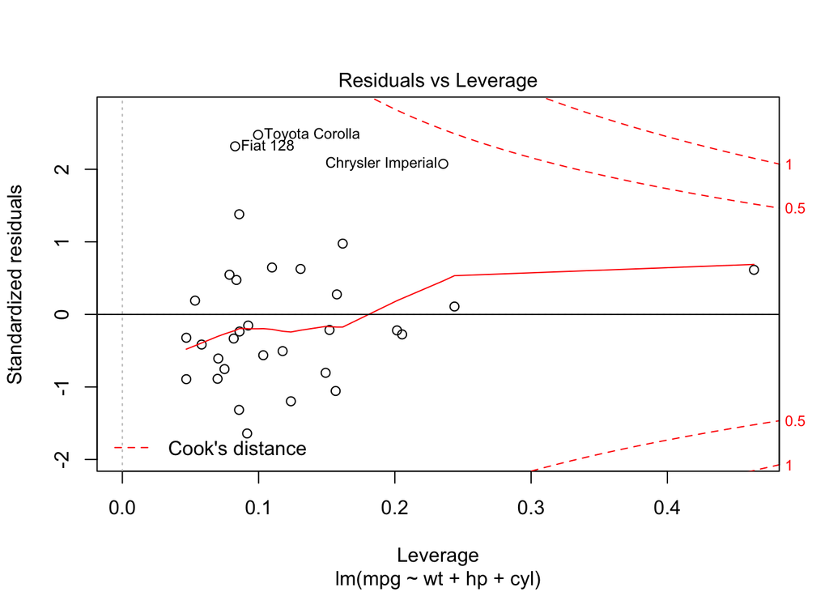

```r
abline(h=0)
```

##### Feature selection.

What features (covariates) should we include in the model? One thought is to eliminate all features with a significance (p-value) higher than some threshold- typically .05. Note that it may be important to retain some or all of the features as they may show their relationship to the outcome (through their estimated coefficient). Remember that one use of a linear model is to see how certain features of interest affect the outcome.

There are two methods for selecting features based on their p-values: forward selection and backward elimination. In forward selection, features are added to the model one at a time starting with one feature. A feature is retained if its p-value is less than the threshold. Backwards elimination starts with a model that includes all features. At each step, the feature with the highest p-value is removed. The elimination stops when all features are significant.

Some caveats: - there is a lot of interaction between features, and p-values are not 100% trustworthy. - p-values become lower for the remaining features when one feature is removed, inflating their importance. - this tends to produce smaller models that might not be useful for explaining the research question. Again, the goal may be to explain a phenomenon, not predict it.

Let’s manually step through a backwards elimination. Q7(2pts): Fit this model of the mtcars data set: mpg~cyl+disp+hp+drat+wt+qsec+vs+am+gear+carb and display the summary.

```r
intercept <- fitCar$coefficients[[1]]
parameter <- fitCar$coefficients[[2]]

fit<- lm(mpg ~ cyl + disp + hp + drat + wt + qsec + vs + am + gear + carb, data = mtcars)
summary(fit)
```

```
##
## Call:
## lm(formula = mpg ~ cyl + disp + hp + drat + wt + qsec + vs +
##     am + gear + carb, data = mtcars)
##
## Residuals:
##     Min      1Q  Median      3Q     Max
## -3.4506 -1.6044 -0.1196  1.2193  4.6271
##
## Coefficients:
##             Estimate Std. Error t value Pr(>|t|)
## (Intercept) 12.30337   18.71788   0.657   0.5181
## cyl         -0.11144    1.04502  -0.107   0.9161
## disp         0.01334    0.01786   0.747   0.4635
## hp          -0.02148    0.02177  -0.987   0.3350
## drat         0.78711    1.63537   0.481   0.6353
## wt          -3.71530    1.89441  -1.961   0.0633 .
## qsec         0.82104    0.73084   1.123   0.2739
## vs           0.31776    2.10451   0.151   0.8814
## am           2.52023    2.05665   1.225   0.2340
## gear         0.65541    1.49326   0.439   0.6652
## carb        -0.19942    0.82875  -0.241   0.8122
## ---
## Signif. codes:  0 '***' 0.001 '**' 0.01 '*' 0.05 '.' 0.1 ' ' 1
##
## Residual standard error: 2.65 on 21 degrees of freedom
## Multiple R-squared:  0.869,  Adjusted R-squared:  0.8066
## F-statistic: 13.93 on 10 and 21 DF,  p-value: 3.793e-07
```

You will see that cyl has the highest p-value, so remove it, refit and display the new model summary. This is accomplished with the following statements:

```r
fit<- update(fit, . ~ . -cyl)
summary(fit)
```

```
##
## Call:
## lm(formula = mpg ~ disp + hp + drat + wt + qsec + vs + am + gear +
##     carb, data = mtcars)
##
## Residuals:
##     Min      1Q  Median      3Q     Max
## -3.4286 -1.5908 -0.0412  1.2120  4.5961
##
## Coefficients:
##             Estimate Std. Error t value Pr(>|t|)
## (Intercept) 10.96007   13.53030   0.810   0.4266
## disp         0.01283    0.01682   0.763   0.4538
## hp          -0.02191    0.02091  -1.048   0.3062
## drat         0.83520    1.53625   0.544   0.5921
## wt          -3.69251    1.83954  -2.007   0.0572 .
## qsec         0.84244    0.68678   1.227   0.2329
## vs           0.38975    1.94800   0.200   0.8433
## am           2.57743    1.94035   1.328   0.1977
## gear         0.71155    1.36562   0.521   0.6075
## carb        -0.21958    0.78856  -0.278   0.7833
## ---
## Signif. codes:  0 '***' 0.001 '**' 0.01 '*' 0.05 '.' 0.1 ' ' 1
##
## Residual standard error: 2.59 on 22 degrees of freedom
## Multiple R-squared:  0.8689, Adjusted R-squared:  0.8153
## F-statistic: 16.21 on 9 and 22 DF,  p-value: 9.031e-08
```

Q8(2pts): Now, continue to remove individual features in the same manner until you have features with p-values less than .05. (Don’t remove the intercept). Don’t enter the individual update statements you execute here, but enter the formula for the model you end up with:

[output not shown]

Q9(4pts): Now enter the statement that fits your final model along with the call to summary:

```r
fit2<- lm(mpg ~ cyl + disp + hp + drat + wt + qsec + vs + am + gear + carb, data = mtcars)
summary(fit2)
```

```
##
## Call:
## lm(formula = mpg ~ cyl + disp + hp + drat + wt + qsec + vs +
##     am + gear + carb, data = mtcars)
##
## Residuals:
##     Min      1Q  Median      3Q     Max
## -3.4506 -1.6044 -0.1196  1.2193  4.6271
##
## Coefficients:
##             Estimate Std. Error t value Pr(>|t|)
## (Intercept) 12.30337   18.71788   0.657   0.5181
## cyl         -0.11144    1.04502  -0.107   0.9161
## disp         0.01334    0.01786   0.747   0.4635
## hp          -0.02148    0.02177  -0.987   0.3350
## drat         0.78711    1.63537   0.481   0.6353
## wt          -3.71530    1.89441  -1.961   0.0633 .
## qsec         0.82104    0.73084   1.123   0.2739
## vs           0.31776    2.10451   0.151   0.8814
## am           2.52023    2.05665   1.225   0.2340
## gear         0.65541    1.49326   0.439   0.6652
## carb        -0.19942    0.82875  -0.241   0.8122
## ---
## Signif. codes:  0 '***' 0.001 '**' 0.01 '*' 0.05 '.' 0.1 ' ' 1
##
## Residual standard error: 2.65 on 21 degrees of freedom
## Multiple R-squared:  0.869,  Adjusted R-squared:  0.8066
## F-statistic: 13.93 on 10 and 21 DF,  p-value: 3.793e-07
```

Notice the model error did not change very much. This process did select features with the most “explanatory” power- at least measured by p-values, but did not alter the basic error of the model. Also be aware that different combinations of features can result in different significance levels.